# Mutational Signature Analysis using mutSignatures

Damiano Fantini

2022-08-24

## The mutSignatures R pipeline

One of the hallmarks of cancer is the accumulation of somatic mutations. Processes including exposure to carcinogens, DNA damage and inaccurate DNA repair may drive the formation of characteristic non-random patterns of DNA mutations, which are also known as **mutational signatures**.

There are several bioinformatic pipelines that allow analysis of mutational signatures. Here, we will use the `mutSignatures` R library to perform such analysis. This library was described in a [2020 Sci.Rep. paper](https://doi.org/10.1038%2Fs41598-020-75062-0) and is available on *CRAN*, and on *GitHub* at the following URL: https://github.com/dami82/mutSignatures. You can install the latest version (at this time, ver `2.1.5`) of the library in your R environment using the `devtools` R package and executing the following line:

```
devtools::install_github("dami82/mutSignatures", force = TRUE, build_vignettes = TRUE)
```

Additional documentation to help getting started with the `mutSignatures` R library is available online ([CRAN vignette](https://cran.r-project.org/web/packages/mutSignatures/vignettes/get_sarted_with_mutSignatures.html); [Website](http://www.mutsignatures.org/); [2020 Sci.Rep. Paper](https://doi.org/10.1038%2Fs41598-020-75062-0) and [Supplementary Materials](https://www.ncbi.nlm.nih.gov/pmc/articles/PMC7589488/bin/41598_2020_75062_MOESM1_ESM.pdf)).

## Goal of the analysis

The goal of this vignette is to describe all steps of a typical mutational signatures analysis performed using `mutSignatures`. A list of n=60 VCF files is used as input. These VCF files were generated using unrestricted publicly available TCGA Bladder Cancer (BLCA) data ([input TCGA MAF available here](https://gdac.broadinstitute.org/runs/analyses__2016_01_28/reports/cancer/BRCA-TP/MutSigNozzleReport2CV/BRCA-TP.final_analysis_set.maf): this file was pre-processed, re-foprmatted, and exploded into donor-specific VCF files).

The steps covered in the vignette include:

- Data import from bladder cancer VCF files and data pre-processing
- Counting 3-nucleotide mutation types
- *De novo* extraction of mutational signatures
- Visualization and data export
- Deconvolution of mutation data using previously identified mutational signatures

## Notes

- The input VCF files used in this analysis were generated as described here: [build_input_files_src__v01.html](https://github.com/dami82/mutSignatures).
- A total of n=30 VCF files are used for *de novo* signature extraction; also, a number of n=30 are used for deconvolution.

## Implementation

### Data import from VCF files and data pre-processing

Data import and pre-processing is the first phase of this analysis. Often, mutation data are stored in a catalog of **Variant Call Format (VCF)** files (for more info about the VCF specifications, see http://samtools.github.io/hts-specs/). The VCF data parsing and pre-processing involves 6 steps:

1- VCF file data are parsed via the `importVCFfiles()` function and used to return a large `data.frame`.

2- The `filterSNV()` function removes INDELS and non-SNV mutations from the `data.frame`.

3- Additional filtering (optional) can be performed by the user for example to remove variants with a low Phred score or to edit seqNames (*i.e.,* chromosome names) or sample identifiers as needed.

4- Using the appropriate Reference `BSgenome` object, the `attachContext()` function retrieves the 3-nucleotide context at each SNV genomic position.

5- The `removeMismatchMut()` function applies a final filter where SNVs are removed if mismatches are detected between expected and observed (reference) DNA sequences

6- Mutation types (*mutTypes*) are then computed for each SNV following the standards proposed by the Sanger Institute (with pyrimidines as reference base) via the `attachMutType()` function.

The code shown below illustrates how to execute all data import and pre-processing steps:

```r
# Load libs
#
library(mutSignatures)
library(dplyr)
library(ggplot2)
library(BSgenome.Hsapiens.UCSC.hg19)
library(kableExtra)

## 1) Data Parsing from VCF files
##

# import mutation data from a list of VCF files
vcf_ext <- 'vcf.gz'
de_novo_fld <- 'VCF_de_novo/'
my_vcfs <- grep(pattern = vcf_ext, dir(de_novo_fld), value = TRUE)
my_vcfs <- paste0(de_novo_fld, my_vcfs)
head(my_vcfs)
```

```
# [1] "VCF_de_novo/TCGA_A1_A0SI_01__simulated.vcf.gz"
# [2] "VCF_de_novo/TCGA_A2_A0SY_01__simulated.vcf.gz"
# [3] "VCF_de_novo/TCGA_A2_A0YK_01__simulated.vcf.gz"
# [4] "VCF_de_novo/TCGA_A8_A07L_01__simulated.vcf.gz"
# [5] "VCF_de_novo/TCGA_A8_A08H_01__simulated.vcf.gz"
# [6] "VCF_de_novo/TCGA_A8_A0A6_01__simulated.vcf.gz"
```

```r
# Read a list of VCF files via importVCFfiles()
x <- importVCFfiles(vcfFiles = my_vcfs)

# Check data.frame dims
dim(x)
```

```
# [1] 12570     9
```

```r
## 2) Remove INDELS and non-SNV mutations
##
x <- filterSNV(dataSet = x,                     # input data.frame
               seq_colNames = c("REF", "ALT"))  # columns w/ sequence data

# Check data.frame dims
dim(x)
```

```
# [1] 12251     9
```

```r
## 3) Optional filtering & editing
##

# Optional: custom filtering (eg. minimum PHRED QUALITY of 10)
# Optional: adjust SAMPLE identifiers
# filtering performed via `dplyr`
x <- x %>%
  dplyr::filter(QUAL >= 10) %>%
  mutate(SAMPLEID = sub('__simulated$', '', .$SAMPLEID)) %>%
  mutate(SAMPLEID = gsub('[[:punct:]]', '-', toupper(.$SAMPLEID)))

# Check data.frame dims
dim(x)
```

```
# [1] 7499    9
```

```r
## 4) Attach 3-nt context
##
hg19 <- BSgenome.Hsapiens.UCSC.hg19::BSgenome.Hsapiens.UCSC.hg19
x <- attachContext(mutData = x,                  # input data.frame
                   BSGenomeDb = hg19,            # Reference Genome object
                   chr_colName = 'CHROM',        # seqNames column
                   start_colName = 'POS',        # genomic position column
                   end_colName = 'POS',          # for VCF files, same as above
                   nucl_contextN = 3,            # how large shall the context be
                   context_colName = 'context')  # name of the column being added
```

```
# 0 rows were excluded from analysis
```

```
# Removing out-of-bounds positions...  0 records were removed.
# Done!
```

```r
# Check data.frame dims
dim(x)
```

```
# [1] 7499   10
```

```r
## 5) Remove mismatches (positions whose VCF reference does not match the
##    corresponding genome sequence)
##
x <- removeMismatchMut(mutData = x,                  # input data.frame
                       refMut_colName = "REF",       # column name for ref base
                       context_colName = "context",  # column name for context
                       refMut_format = "N")          # reference format ('N')

# Check data.frame dims
dim(x)
```

```
# [1] 7499   10
```

```r
## 6) Compute mutType (according to the standards proposed by the Sanger
##    Institute, i.e. with pyrimidines as reference base)
##
x <- attachMutType(mutData = x,                      # as above
                   ref_colName = "REF",              # column name for ref base
                   var_colName = "ALT",              # column name for mut base
                   context_colName = "context")      # context colname
```

```
# Assigning mutation types ..................... Done!
# Now applying RevCompl transformation. Done!
# Final formatting. Done!
```

```r
# Check data.frame dims
dim(x)
```

```
# [1] 7499   11
```

```r
# Visualize head of the resulting data.frame
x %>%
  head() %>% kable() %>%
  kable_styling(bootstrap_options = "striped", font_size = 7, full_width = FALSE)
```

| CHROM | POS | ID | REF | ALT | QUAL | FILTER | INFO | SAMPLEID | context | mutType |
| --- | --- | --- | --- | --- | --- | --- | --- | --- | --- | --- |
| chr1 | 7886690 | . | G | A | 19.09 | . | . | TCGA-A1-A0SI-01 | CGA | T[C>T]G |
| chr1 | 23688993 | . | G | C | 13.75 | . | . | TCGA-A1-A0SI-01 | TGA | T[C>G]A |
| chr1 | 31769474 | . | C | T | 15.91 | . | . | TCGA-A1-A0SI-01 | TCC | T[C>T]C |
| chr1 | 109479811 | . | C | G | 18.57 | . | . | TCGA-A1-A0SI-01 | TCT | T[C>G]T |
| chr1 | 152081408 | . | C | T | 13.33 | . | . | TCGA-A1-A0SI-01 | TCA | T[C>T]A |
| chr1 | 158687142 | . | G | C | 12.51 | . | . | TCGA-A1-A0SI-01 | TGA | T[C>G]A |

### Counting 3-nucleotide mutation types

Counting mutation types by samples is the last step of the pre-processing phase and is performed using the `countMutTypes()` function.

The input is a data.frame that includes at least two columns:

- a column with info about samples (sample identifiers)
- a column listing mutation types (*e.g.,* 3-nt mutTypes)

The output is a `mutationCounts` object.

```r
## Counting 3-nucleotide mutation types
##
blca_counts <- countMutTypes(mutTable = x,
                             mutType_colName = 'mutType',
                             sample_colName = 'SAMPLEID')

# Output
blca_counts
```

```
#  Mutation Counts object - mutSignatures
#
#  Total num of MutTypes: 96
#  MutTypes: A[C>A]A, A[C>A]C, A[C>A]G, A[C>A]T, A[C>G]A ...
#
#  Total num of Samples: 30
#  Sample Names: TCGA-A1-A0SI-01, TCGA-A2-A0SY-01, TCGA-A2-A0YK-01, TCGA-A8-A07L-01, TCGA-A8-A08H-01 ...
```

### *De novo* extraction of mutational signatures

A *de novo* extraction of mutational signatures implies performing non-negative matrix factorization (NMF) to identify patterns that can explain the pattern of somatic mutations observed in a set of cancer samples. The `mutSignatures` R library supports Brunet’s algorithm for NMF (described in this [2004 PNAS paper](https://doi.org/10.1073/pnas.0308531101)) as well as an alternative NMF algorithm (for more info see our [2020 Sci Rep paper](https://doi.org/10.1038%2Fs41598-020-75062-0)). This step is performed via the `decipherMutationalProcesses()` function, which takes two inputs:

- a `mutationCounts` object (like the object we instantiated earlier)
- a `mutFrameworkParams` object, which defines the parameters for the analysis

Completing this step may take several minutes, depending on the compute resources (amount of memory and number of cores) and the complexity of the problem (number of samples, number of signatures).

```r
## De novo extraction of mutational signatures
##

# Define parameters for the non-negative matrix factorization procedure.
blca_params <- setMutClusterParams(
    num_processesToExtract = 5,       # num signatures to extract
    num_totIterations = 30,          # bootstrapping: usually 500-1000
    num_parallelCores = 1,            # num of cores (parallelization)
    seed = 12345)                     # random seed (optional)

# De Novo Extraction of Mutational Signatures (may take a while)
blca_analysis <- decipherMutationalProcesses(input = blca_counts,
                                             params = blca_params)
```

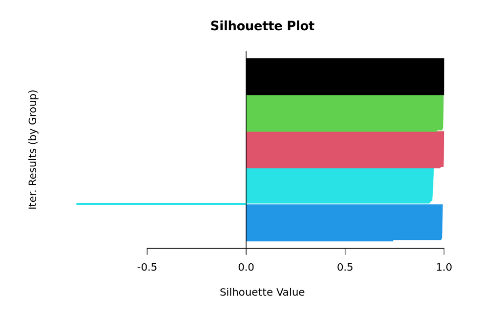

### Visualization and data export

Results (and intermediates) of a *de novo* signature extraction job are returned as elements of a `list` object. Specifically, there are two important elements to inspect:

- Mutational signatures: `[['Results']][['signatures']]` element (`mutationSignatures` object).
- Signature exposures (*i.e.* signature activities): `[['Results']][['exposures']]` element (`mutSignExposures` object).

Both objects can be used to build barplots via the `msigPlot()` or exported to `data.frame` objects using the `mutSignatures::as.data.frame()` method. Also, `mutSignatures` comes with a function to compare newly-extracted mutational signatures with other reference signatures, such as the COSMIC mutational signatures (see https://cancer.sanger.ac.uk/signatures/). To do so, the `matchSignatures()` computes the `cosine` distance between signatures based on the corresponding mutType frequencies and then returns pairwise similarity scores where `similarity = 1 - distance`. Summary heatmaps are automatically built.

**Mutational Signatures**

The code below retrieves all n=5 mutational signatures (from the output of our *de novo* extraction job), and generates barplots to visualize them. Each bar indicates the frequency (y-axis) of a certain mutation type (x-axis) in the signature (values are winsorized at 0.2); 3-nt mutTypes are grouped and colored according to the corresponding SNV.

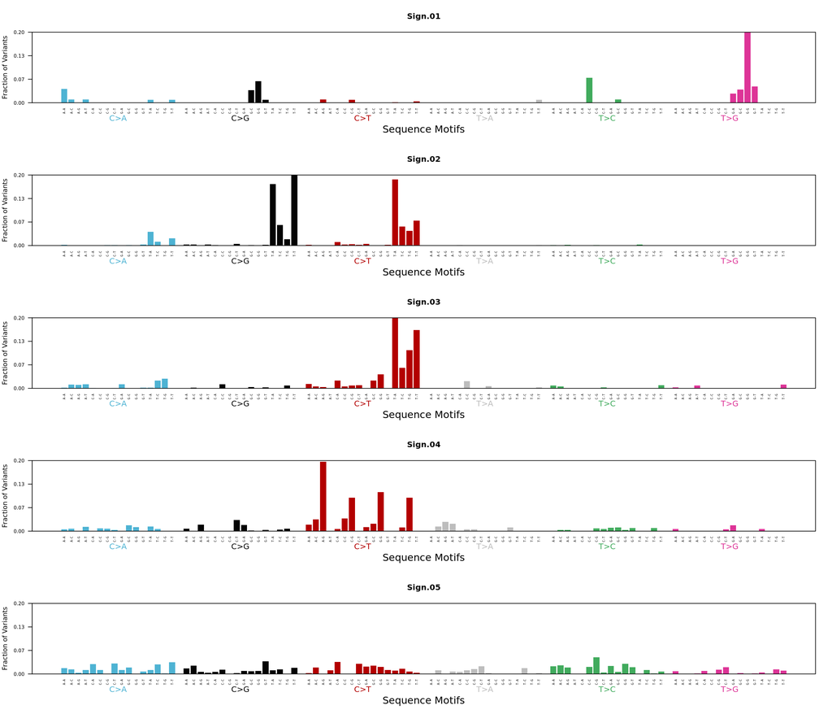

```r
## Visualization and data export
##

# Get resulting Signatures
de_novo_sigs <- blca_analysis$Results$signatures

# Visualize individual signatures
par(mfrow = c(5, 1))
msigPlot(de_novo_sigs, signature = 1)
msigPlot(de_novo_sigs, signature = 2)
msigPlot(de_novo_sigs, signature = 3)
msigPlot(de_novo_sigs, signature = 4)
msigPlot(de_novo_sigs, signature = 5)
```

**Signature Exposures**

The code below retrieves the signatures exposures / activities (from the output of our *de novo* extraction job), and generates barplots to visualize those results. Each bar corresponds to a sample (x-axis) and stacked colors indicate the contribute of different signatures to the total number of mutations (y-axis) in each sample.

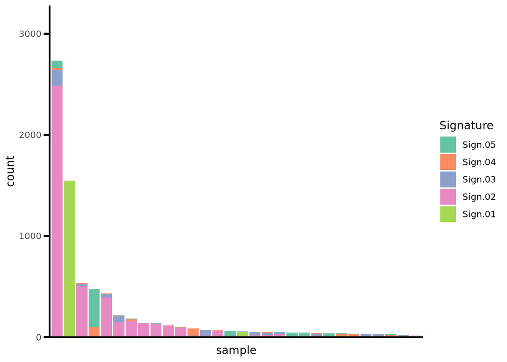

```r
# Exposures
de_novo_expos <- blca_analysis$Results$exposures
my_pal <- c('#66c2a5', '#fc8d62', '#8da0cb', '#e78ac3', '#a6d854')
msigPlot(de_novo_expos) +
  scale_fill_manual(values = my_pal)
```

**Compare Mutational Signatures**

The code below retrieves COSMIC mutational signatures that were described as important in bladder cancer (see https://doi.org/10.1038/nature12477) and compares them to our *de novo*-extracted signatures. Results are visualized as a heatmap where x-axis indicates reference (COSMIC) signatures, y-axis indicates query (*de novo*) signatures, and box (red) intensity tracks with similarity (computed as `1 - cosine distance`). The plot shows that 4 out of 5 signatures identified in this analysis were highly similar to BLCA-specific COSMIC, while one (featuring high frequency of T>G mutations) could NOT be matched to COSMIC 1/2/5/13.

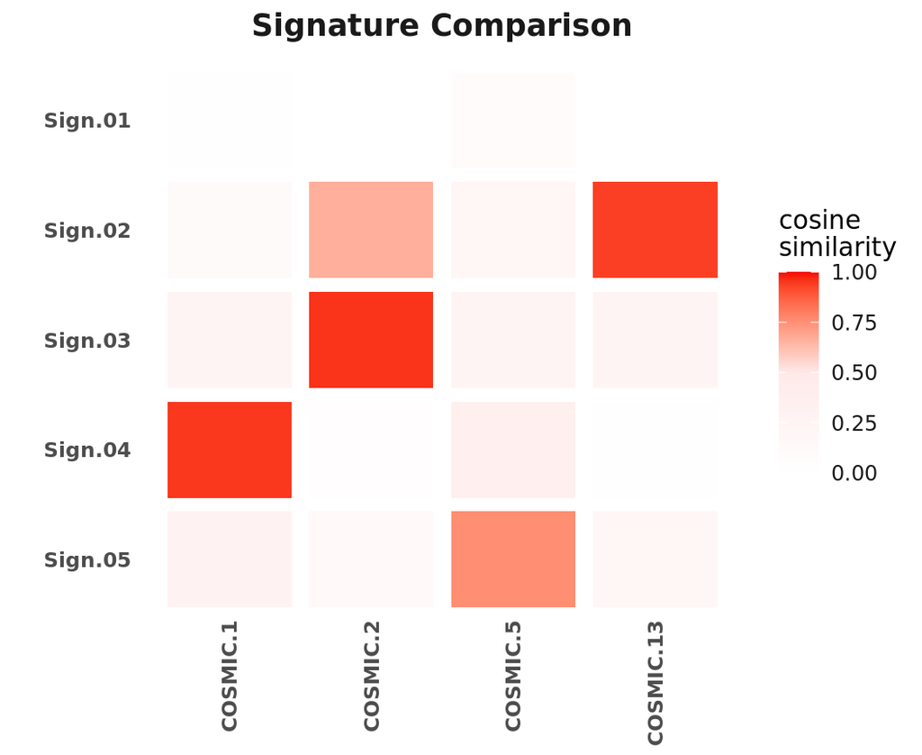

```r
# Get COSMIC signatures (Sanger Institute)
cosmix <- getCosmicSignatures()

# Subset COSMIC signatures that are prevalent in Bladder Cancer (literature)
blca_cosmix <- cosmix[c(1,2,5,13)]

# Compare signatures
blca_new_vs_cosmix <- matchSignatures(de_novo_sigs, blca_cosmix)

# Show heatmap
blca_new_vs_cosmix$plot
```

**Object Management and data export**

The library comes with several methods to manage and work with `mutationSignatures` objects (as well as objects of other classes). Examples include the `[`, `setSignatureNames`, `getSignatureIdentifiers` and `as.data.frame` methods. SOme examples are shown below.

```r
# Reorder or subset signatures in a mutSignatures object
de_novo_sigs <- de_novo_sigs[c(3, 4, 5, 2, 1)]

# Rename signatures via setSignatureNames()
de_novo_sigs <- setSignatureNames(de_novo_sigs, paste0('neoBLCA_', LETTERS[1:5]))

# Get / show Signature Names
getSignatureIdentifiers(de_novo_sigs)
```

```
FALSE [1] "neoBLCA_A" "neoBLCA_B" "neoBLCA_C" "neoBLCA_D" "neoBLCA_E"
```

```r
# Export to data.frame
de_novo_sigs_df <- mutSignatures::as.data.frame(de_novo_sigs)

# Show head
de_novo_sigs_df %>%
  head(12) %>% kable() %>%
  kable_styling(bootstrap_options = "striped", font_size = 8, full_width = FALSE)
```

|  | neoBLCA_A | neoBLCA_B | neoBLCA_C | neoBLCA_D | neoBLCA_E |
| --- | --- | --- | --- | --- | --- |
| A[C>A]A | 0.0017082 | 0.0054688 | 0.0165415 | 0.0021316 | 0.0391519 |
| A[C>A]C | 0.0106755 | 0.0067602 | 0.0133309 | 0.0001606 | 0.0095017 |
| A[C>A]G | 0.0098510 | 0.0000548 | 0.0030788 | 0.0000000 | 0.0000000 |
| A[C>A]T | 0.0116331 | 0.0121004 | 0.0111925 | 0.0000069 | 0.0094407 |
| A[C>G]A | 0.0000000 | 0.0073106 | 0.0159203 | 0.0031991 | 0.0000000 |
| A[C>G]C | 0.0016318 | 0.0004796 | 0.0231791 | 0.0033695 | 0.0000000 |
| A[C>G]G | 0.0000000 | 0.0179954 | 0.0055006 | 0.0002832 | 0.0000000 |
| A[C>G]T | 0.0000000 | 0.0000715 | 0.0035418 | 0.0031387 | 0.0002361 |
| A[C>T]A | 0.0125536 | 0.0184569 | 0.0026294 | 0.0016644 | 0.0002506 |
| A[C>T]C | 0.0056882 | 0.0335766 | 0.0185394 | 0.0000000 | 0.0003406 |
| A[C>T]G | 0.0034639 | 0.1965835 | 0.0000000 | 0.0002442 | 0.0091567 |
| A[C>T]T | 0.0000000 | 0.0002409 | 0.0104752 | 0.0000000 | 0.0000000 |

### Deconvolution of mutation data using previously identified mutational signatures

The `mutSignatures` library is a flexible framework and supports deconvolution of mutation data using pre-defined mutational signatures (*e.g.,* COSMIC signatures, signatures that were identified before or by other groups). In this case, the pre-processing phase is virtually unchanged, but the NMF step is replaced by a fast combinatorial non-negative least-square algorithm. This step is performed via the `resolveMutSignatures()` function. Results only include signature exposures (activities).

The code below shows how to streamline all pre-processing steps (using `dplyr` pipes) and then execute the `resolveMutSignatures()` function. Results are retrieved and used to generate a barplot summarizing signature exposures.

```r
## Read VCF files in
##
vcf_ext <- 'vcf.gz'
deconv_fld <- 'VCF_deconv/'
my_vcfs <- grep(pattern = vcf_ext, dir(deconv_fld), value = TRUE)
my_vcfs <- paste0(deconv_fld, my_vcfs)

## Pre-processing + Counting (same as above) via dplyr pipes
##
blca_deco_counts <- mutSignatures::importVCFfiles(vcfFiles = my_vcfs) %>%

  dplyr::filter(QUAL >= 10) %>%
  mutate(SAMPLEID = sub('__simulated$', '', .$SAMPLEID)) %>%
  mutate(SAMPLEID = gsub('[[:punct:]]', '-', toupper(.$SAMPLEID))) %>%

  filterSNV(seq_colNames = c("REF", "ALT")) %>%

  attachContext(BSGenomeDb = BSgenome.Hsapiens.UCSC.hg19,
                chr_colName = 'CHROM', start_colName = 'POS',
                end_colName = 'POS', nucl_contextN = 3,
                context_colName = 'context') %>%

  removeMismatchMut(refMut_colName = "REF", context_colName = "context",
                    refMut_format = "N")    %>%

  attachMutType(ref_colName = "REF", var_colName = "ALT",
                context_colName = "context") %>%

  countMutTypes(mutType_colName = 'mutType', sample_colName = 'SAMPLEID')
```

```
FALSE 0 rows were excluded from analysis
```

```
FALSE Removing out-of-bounds positions...  0 records were removed.
FALSE Done!
FALSE Assigning mutation types ..................... Done!
FALSE Now applying RevCompl transformation. Done!
FALSE Final formatting. Done!
```

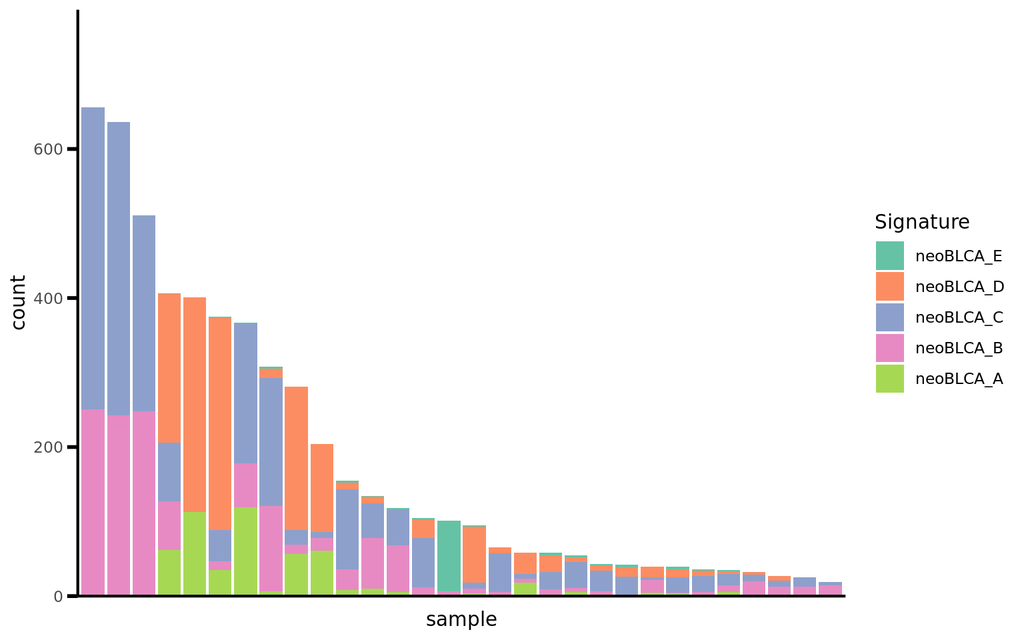

```r
## Deconvolute using resolveMutSignatures()
##
blca_deco_analysis <- resolveMutSignatures(mutCountData = blca_deco_counts,
                                           signFreqData = de_novo_sigs,
                                           byFreq = TRUE)

## Fetch Results, Visualize Exposures
##

# Get results
blca_deco_expos <- blca_deco_analysis$results$count.result

# Plot
my_pal <- c('#66c2a5', '#fc8d62', '#8da0cb', '#e78ac3', '#a6d854')
msigPlot(blca_deco_expos) + scale_fill_manual(values = my_pal)
```

Similar to what shown above, `mutSignExposures` objects can be exported to `data.frame` using the `as.data.frame` method.

```r
## Export as data.frame
##
blca_deco_expos_df <- mutSignatures::as.data.frame(blca_deco_expos,
                                                   transpose = TRUE)

# Show head
blca_deco_expos_df %>%
  head(n = 12) %>% kable() %>%
  kable_styling(bootstrap_options = "striped", font_size = 8, full_width = FALSE)
```

|  | neoBLCA_A | neoBLCA_B | neoBLCA_C | neoBLCA_D | neoBLCA_E |
| --- | --- | --- | --- | --- | --- |
| TCGA-A1-A0SK-01 | 0.0000000 | 20.162678 | 8.699276 | 3.067997 | 0.1731292 |
| TCGA-A2-A0T0-01 | 0.0000000 | 5.632186 | 51.322013 | 8.772327 | 0.1511379 |
| TCGA-A2-A0T6-01 | 0.1704449 | 6.135068 | 0.000000 | 0.000000 | 95.0413617 |
| TCGA-A2-A3XT-01 | 0.0000000 | 0.000000 | 25.726029 | 12.661936 | 3.8464642 |
| TCGA-A7-A56D-01 | 17.5827260 | 5.977260 | 6.005608 | 28.789068 | 0.1686060 |
| TCGA-A8-A07R-01 | 7.7496803 | 27.969026 | 107.452588 | 9.351179 | 1.9933796 |
| TCGA-A8-A09M-01 | 0.0000000 | 5.083025 | 21.906845 | 7.147579 | 1.9435560 |
| TCGA-A8-A09Z-01 | 0.0000000 | 242.125870 | 393.937652 | 0.000000 | 0.0000000 |
| TCGA-AC-A3W5-01 | 0.0000000 | 9.218417 | 23.350156 | 22.287377 | 3.4621054 |
| TCGA-AC-A5EH-01 | 5.6610408 | 4.809341 | 34.951839 | 6.925126 | 2.2423852 |
| TCGA-AC-A5XS-01 | 56.3708723 | 12.740896 | 19.272202 | 192.714542 | 0.0000000 |
| TCGA-AN-A04C-01 | 0.0000000 | 12.237632 | 8.856280 | 5.807098 | 0.0000000 |

Notably, the output returned by `resolveMutSignatures()` includes two `mutSignExposures` objects:

- Total Mutation Counts by Signature in each sample: `[['results']][['count.result']]` element (`mutSignExposures` object).
- Relative proportion of Signature activities (frequency) in each sample (sums up to unity): `[['results']][['freq.result']]` element (`mutSignExposures` object).

Both results can be exported as `data.frame` and used in downstream analyses. For example, here we fetch both objects, transform them in molten data.frames, bind them together, and use the resulting object to build a stacked signature exposure barplot (top panel, total counts by signature; bottom panel, proporion of counts by signature).

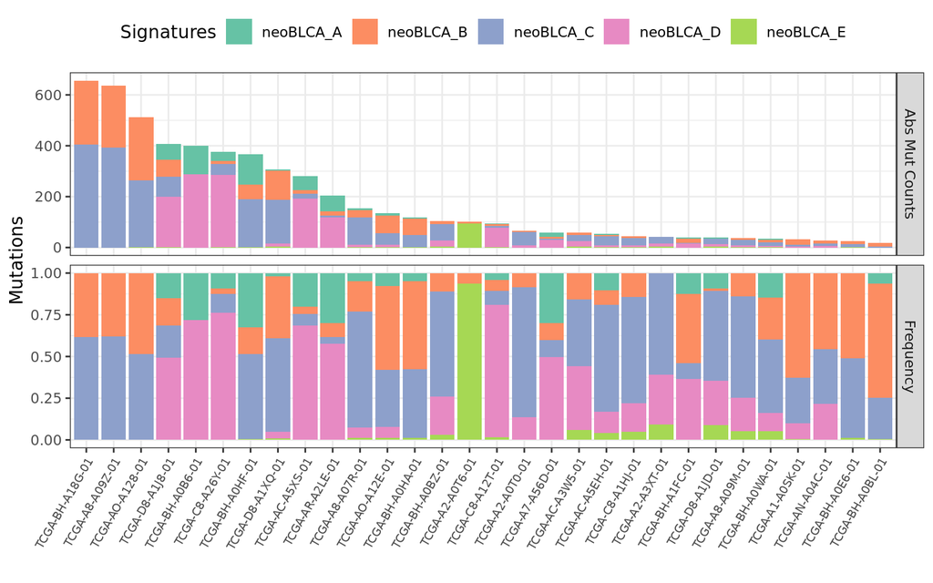

```r
## Downstream analyses and Advanced Visualization
##

# Export count version as well as freq.version as data.frames
blca_xp_cnt <- blca_deco_analysis$results$count.result
blca_xp_cnt_df <- mutSignatures::as.data.frame(blca_xp_cnt, transpose = TRUE)

blca_xp_frq <- blca_deco_analysis$results$freq.result
blca_xp_frq_df <- mutSignatures::as.data.frame(blca_xp_frq, transpose = TRUE)

# Transform TOT_counts exposure data.frame
tmp_df1 <- as.matrix(blca_xp_cnt_df) %>%
  reshape2:::melt.matrix(varnames = c('ID', 'Sign')) %>%
  mutate(panel = 'Abs Mut Counts')

# Transform FREQ exposure data.frame
tmp_df2 <- as.matrix(blca_xp_frq_df) %>%
  reshape2:::melt.matrix(varnames = c('ID', 'Sign')) %>%
  mutate(panel = 'Frequency')

# define sample order
sample_ord <- apply(blca_xp_cnt_df, 1, sum) %>%
  sort(decreasing = TRUE) %>% names()

# Bind together
tmp <- rbind(tmp_df1, tmp_df2)  %>%
  mutate(ID = factor(.$ID, levels = sample_ord))

# Build barplot
ggplot(tmp, aes(x = ID, y = value, fill = Sign)) +
  geom_bar(stat = 'identity', position = position_stack()) +
  theme_bw() +
  facet_grid(rows = vars(panel), scales = 'free', space = 'fixed') +
  ylab('Mutations') + xlab('') +
  scale_fill_manual('Signatures', values = my_pal) +
  theme(axis.text.x = element_text(angle = 60, size = 7, hjust = 1, vjust = 1),
        legend.position = 'top')
```

## Additional Considerations

Below, we included a list of comments and notes about specific steps of the analyses presented in this vignette. Attention should be paid to the following items as they are very important for a succesfull implementation of the pipeline and interpretation of the results.

1- **Filtering mutations**. This pipeline is meant to analyze somatic mutations, and hence it is very important to filter out single nucleotide polymorphisms as well as other variants (*e.g.*, germline mutations or technical artifacts). Filtering should be performed at the VCF stage or during pre-processing. Filtering approaches may include: *i)* excluding variants detected in a non-cancer sample from the same donor; *ii)* removing well-documented single nucleotide polymorphisms (for example, see https://www.ncbi.nlm.nih.gov/snp/); *iii)* excluding low-confidence mutations (*e.g.,* filter based on PHRED scores as shown above, or on variant allele frequency).

2- **Filtering samples**. We recommend excluding samples with very low mutation burden from any mutational signature extraction or deconvolution job, since results may be inaccurate for these samples. We typically exclude samples with a total number of SNVs smaller than 15-30 (depending on the dataset). For example, in the analysis above, the sample with the smallest number of SNVs had n=17 SNVs.

```r
mutSignatures::as.data.frame(blca_counts) %>%
  t() %>% apply(MARGIN = 1, FUN = sum) %>% min()
```

```
#> [1] 17
```

3- **Assure consistency between VCF files and the BSGenome object**. Make sure that the same reference genome was used for read mapping as well as for the mutational signature analysis. In other words, it is not possible to run this pipeline using a human `hg19` reference if reads were mapped to human `hg38` or vice versa. If unsure about how the VCF files were generated, you may want to look at the VCF meta-information lines (these may include info about the reference genome and/or the lengths of chromosome sequences used for read mapping and variant calling). Based on that information, identify the most appropriate annotation library (see https://bioconductor.org/packages/release/data/annotation/) to use in the analysis.

4- **Assure consistency of sequence names**. Even if VCF files and the BSGenome object were built using compatible genome references (*e.g.,* human `hg19`), it is possible that sequence names in the VCF files (*i.e.,* values in the `CHROM` column; for example `1`, `2`, `3`, …) do NOT match the corresponding values stored in the `BSGenome` object (TYPICALLY, `chr1`, `chr2`, `chr3`, …). Before running a signature analysis, please assure consistency of seqnames as shown below.

```r
## Read VCF file
ex01 <- mutSignatures::importVCFfiles(vcfFiles = 'VCF_extra/example_01.vcf')
head(ex01)
```

```
#>   CHROM       POS ID REF ALT  QUAL FILTER INFO   SAMPLEID
#> 1     1  27057874  .   C   T 35.00      .    . example_01
#> 2     1  66081710  .   C   T 20.40      .    . example_01
#> 3     1 146756023  .   G   A 15.22      .    . example_01
#> 4     1 152082173  .   C   G 14.05      .    . example_01
#> 5     1 155237829  .   T   C 13.61      .    . example_01
#> 6     1 179782251  .   G   A 33.00      .    . example_01
```

```r
## Access BSGenome seqnames
hg19 <- BSgenome.Hsapiens.UCSC.hg19
head(GenomeInfoDb::seqnames(hg19))
```

```
#> [1] "chr1" "chr2" "chr3" "chr4" "chr5" "chr6"
```

```r
## Compare seqNames
sum(ex01$CHROM %in% seqnames(BSgenome.Hsapiens.UCSC.hg19)) / nrow(ex01)
```

```
#> 0
```

```r
## Modify
ex01 <- ex01 %>%
  mutate(CHROM = paste0('chr', .$CHROM))
head(ex01)
```

```
#>   CHROM       POS ID REF ALT  QUAL FILTER INFO   SAMPLEID
#> 1  chr1  27057874  .   C   T 35.00      .    . example_01
#> 2  chr1  66081710  .   C   T 20.40      .    . example_01
#> 3  chr1 146756023  .   G   A 15.22      .    . example_01
#> 4  chr1 152082173  .   C   G 14.05      .    . example_01
#> 5  chr1 155237829  .   T   C 13.61      .    . example_01
#> 6  chr1 179782251  .   G   A 33.00      .    . example_01
```

```r
sum(ex01$CHROM %in% seqnames(BSgenome.Hsapiens.UCSC.hg19)) / nrow(ex01)
```

```
#> 1
```

5- **Selecting the best number of signatures to extract**. Unfortunately, it is not always easy to select the best number of signatures to extract in a *de novo* signature analysis. The most appropriate number should be selected based on the size of the dataset, the extent of inter-sample heterogeneity, preliminary information about similar cancer types (see https://doi.org/10.1038/nature12477), trial an error, evaluation of the mutational signature patterns (how similar / different are the profiles of *de novo*-extracted mutational signatures?), and stability results (silhouette plots). The `mutSignatures` library also provides a function to perform a preliminary assessment of the deconvolution error (% of max error on the training set) with respect to the number of signatures being extracted. This function may provide some insights into the optimal range of signature numbers to extract.

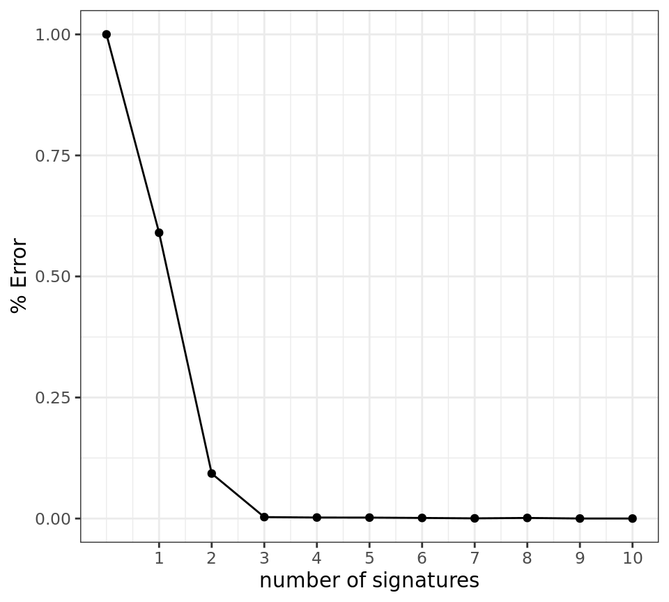

```r
# prelimProcessAssess (this may take a while)
ex02 <- prelimProcessAssess(input = blca_counts, maxProcess = 10, plot = FALSE)

# Build a plot
ggplot(ex02, aes(x=numProcess, y=percentErr)) +
  geom_point() + geom_line() +
  scale_x_continuous(breaks = seq(1, 12, by = 1)) +
  theme_bw() + xlab('number of signatures') + ylab('% Error')
```

7- **Selecting the right set of signatures for a deconvolution analysis**. It is highly recommended to select relevant mutational signatures before performing a mutational signature deconvolution analysis. In other words, we discourage deconvoluting a catalog of mutations against the full set of n=30 COSMIC signatures, since this may identify signatures that are NOT really active in that cancer type. Looking for published results from the same cancer type (for example, see https://doi.org/10.1038/nature12477) and/or running a *de novo* signature extraction analysis may help to identify relevant signatures for a new dataset.

```r
# Deconvolute BLCA via
ex03 <- resolveMutSignatures(mutCountData = blca_deco_counts,
                             signFreqData = cosmix, byFreq = TRUE)

# Get signatures exposures (activities)
ex03_cnt <- ex03$results$count.result

# Prevalent signatures by counts
# Expected: COSMIC-1/2/5/13
# False negative: COSMIC-5 not identified!!
# False positive: COSMIC-6 and COSMIC-3 were identified!
mutSignatures::as.data.frame(ex03_cnt) %>%
  apply(MARGIN = 1, FUN = sum) %>% sort(decreasing = TRUE) %>%
  head()
```

```
#>  COSMIC.6 COSMIC.13  COSMIC.3  COSMIC.2  COSMIC.1 COSMIC.20
#>  963.4687  868.1936  665.6782  580.4145  425.7910  340.2650
```

8- **Parallelization**. Parallelization is supported on multi-core Linux and Unix environments (the feature was never tested on Windows machines). Parallelization can considerably speed up execution times of a *de novo* mutational signature extraction job (as long as the system has enough memory). To enable parallelization, it is sufficient to set the `num_parallelCores` argument (`setMutClusterParams()` function) to a value of 2 or higher.

9- **Working with non-standard mutation types**. All analyses presented in this vignette used 3-nucleotide mutation types formatted according to the convention proposed by the Sanger Institute (*e.g.,* `A[C>A]G`). However, the `mutSignatures` library is mutation-type-agnostinc. Users can define custom mutation types (*e.g.,* `C[G>T]T`, `GA[C>A]G` or `RR[Y>R]R`), count them using `countMutTypes()` and then analyze them using `decipherMutationalProcesses()` and `resolveMutSignatures()`. For more info, see our [2020 Sci.Rep. paper](https://doi.org/10.1038/s41598-020-75062-0) (figure 4).

## Conclusions

- We performed mutational signature analysis using a list of bladder cancer VCF files as input.
  - A number of n=30 VCF files was used for *de novo* signature extraction.
  - A number of n=30 VCF files was used for signature deconvolution (activity attribution).
- We described pre-processing steps to import data from VCF files, perform filtering, retrieve 3-nucleotide genomic context, compile and count mutation types.
  - We also showed how to execute all these steps back-to-back via `dplyr` piping.
- We compared *de novo*-extracted mutational signatures to COSMIC signatures, exported results as `data.frame` and generated plots.
- Finally, we further discussed about additional points that should be kept in mind while designing and performing mutational signature analysis.

## SessionInfo

```r
# sessioninfo
sessionInfo()
```

```
# R version 4.2.1 (2022-06-23)
# Platform: x86_64-pc-linux-gnu (64-bit)
# Running under: Ubuntu 20.04.4 LTS
#
# Matrix products: default
# BLAS:   /usr/lib/x86_64-linux-gnu/blas/libblas.so.3.9.0
# LAPACK: /usr/lib/x86_64-linux-gnu/lapack/liblapack.so.3.9.0
#
# locale:
#  [1] LC_CTYPE=C.UTF-8       LC_NUMERIC=C           LC_TIME=C.UTF-8
#  [4] LC_COLLATE=C.UTF-8     LC_MONETARY=C.UTF-8    LC_MESSAGES=C.UTF-8
#  [7] LC_PAPER=C.UTF-8       LC_NAME=C              LC_ADDRESS=C
# [10] LC_TELEPHONE=C         LC_MEASUREMENT=C.UTF-8 LC_IDENTIFICATION=C
#
# attached base packages:
# [1] stats4    stats     graphics  grDevices utils     datasets  methods
# [8] base
#
# other attached packages:
#  [1] kableExtra_1.3.4                  BSgenome.Hsapiens.UCSC.hg19_1.4.3
#  [3] BSgenome_1.64.0                   rtracklayer_1.56.1
#  [5] Biostrings_2.64.0                 XVector_0.36.0
#  [7] GenomicRanges_1.48.0              GenomeInfoDb_1.32.3
#  [9] IRanges_2.30.0                    S4Vectors_0.34.0
# [11] BiocGenerics_0.42.0               ggplot2_3.3.6
# [13] dplyr_1.0.9                       mutSignatures_2.1.5
# [15] foreach_1.5.2
#
# loaded via a namespace (and not attached):
#  [1] httr_1.4.3                  MatrixGenerics_1.8.1
#  [3] Biobase_2.56.0              sass_0.4.2
#  [5] viridisLite_0.4.0           jsonlite_1.8.0
#  [7] bslib_0.4.0                 highr_0.9
#  [9] GenomeInfoDbData_1.2.8      Rsamtools_2.12.0
# [11] yaml_2.3.5                  pillar_1.8.0
# [13] lattice_0.20-45             glue_1.6.2
# [15] digest_0.6.29               rvest_1.0.2
# [17] colorspace_2.0-3            plyr_1.8.7
# [19] htmltools_0.5.3             Matrix_1.4-1
# [21] XML_3.99-0.10               pkgconfig_2.0.3
```

[output cut: 13 more lines]

```
# [49] munsell_0.5.0               cluster_2.1.3
# [51] DelayedArray_0.22.0         compiler_4.2.1
# [53] jquerylib_0.1.4             systemfonts_1.0.4
# [55] rlang_1.0.4                 grid_4.2.1
# [57] RCurl_1.98-1.8              iterators_1.0.14
# [59] rstudioapi_0.13             rjson_0.2.21
# [61] labeling_0.4.2              bitops_1.0-7
# [63] rmarkdown_2.14              restfulr_0.0.15
# [65] gtable_0.3.0                codetools_0.2-18
# [67] reshape2_1.4.4              R6_2.5.1
# [69] GenomicAlignments_1.32.1    knitr_1.39
# [71] fastmap_1.1.0               utf8_1.2.2
# [73] stringi_1.7.8               Rcpp_1.0.9
# [75] parallel_4.2.1              vctrs_0.4.1
# [77] tidyselect_1.1.2            xfun_0.32
```

Success! || Damiano Fantini, Joshua Meeks & the Meeks’ Lab (Northwestern University, Chicago, IL) || Aug 24, 2022